# HW4

Melissa Luzardo

January 30, 2018

# **MSDS 6306: Doing Data Science**

## Live Session Unit 04 Assignment

## 1. FiveThirtyEight Data (30 points): Navigate on GitHub to https://github.com/rudeboybert/fivethirtyeight and read README.md. It includes everything you need.

1. Install the fivethirtyeight package.

```r
#Install package following instructions using "install.packages("fivethirtyeight")" if not already installed
#Load library
library(fivethirtyeight)
```

## b. In the listing of Data sets in package ‘fivethirtyeight,’ assign the eighteenth data set to an object ‘df.’

```r
#See list of all data set in 538
data(package = "fivethirtyeight")

#Assign the 18th data set ti "df"
df <- college_grad_students
```

## c. Use a more detailed list of the data sets to write out the URL in a comment to the related news story.

```r
#To see a more detailed list of all data sets, see the package vignette:
vignette("fivethirtyeight", package = "fivethirtyeight")
```

```
## starting httpd help server ... done
```

## d. Using R command(s), give the dimensions and column names of this data frame.

```r
#For data frame dimensions
dim(df)
```

```
## [1] 173  22
```

```r
#for data frame names
names(df)
```

```
##  [1] "major_code"
##  [2] "major"
##  [3] "major_category"
##  [4] "grad_total"
##  [5] "grad_sample_size"
##  [6] "grad_employed"
##  [7] "grad_employed_fulltime_yearround"
##  [8] "grad_unemployed"
##  [9] "grad_unemployment_rate"
## [10] "grad_p25th"
## [11] "grad_median"
## [12] "grad_p75th"
## [13] "nongrad_total"
## [14] "nongrad_employed"
## [15] "nongrad_employed_fulltime_yearround"
## [16] "nongrad_unemployed"
## [17] "nongrad_unemployment_rate"
## [18] "nongrad_p25th"
## [19] "nongrad_median"
## [20] "nongrad_p75th"
## [21] "grad_share"
## [22] "grad_premium"
```

## 2. Data Summary (30 points): Use your newly assigned data frame for Question 2.

## a. Write an R command that gives you the column names of the data frame. Right after that, write one that counts the number of columns but not rows. Hint: The number should match one of your numbers in Question 1d for dimensions.

```r
#for data frame names
dfnames <- names(df)
dfnames
```

```
##  [1] "major_code"
##  [2] "major"
##  [3] "major_category"
##  [4] "grad_total"
##  [5] "grad_sample_size"
##  [6] "grad_employed"
##  [7] "grad_employed_fulltime_yearround"
##  [8] "grad_unemployed"
##  [9] "grad_unemployment_rate"
## [10] "grad_p25th"
## [11] "grad_median"
## [12] "grad_p75th"
## [13] "nongrad_total"
## [14] "nongrad_employed"
## [15] "nongrad_employed_fulltime_yearround"
## [16] "nongrad_unemployed"
## [17] "nongrad_unemployment_rate"
## [18] "nongrad_p25th"
## [19] "nongrad_median"
## [20] "nongrad_p75th"
## [21] "grad_share"
## [22] "grad_premium"
```

```r
#for df columns
length(names(df))
```

```
## [1] 22
```

## b. Generate a count of each unique major_category in the data frame. I recommend using libraries to help. To be clear, this should look like a matrix or data frame containing the major_category and the frequency it occurs in the dataset. Assign it to major_count.

```r
#Identify each unique major_category assign to "MajorCategory" vector and create an object with its length
MajorCategory <- unique(df$major_category)
lgMC <- length(MajorCategory)

#Create vector to place counts
Counts <- c(1:lgMC)
for (i in 1:lgMC)
{ Counts[i] <- length(which(df$major_category == MajorCategory[i]))}
major_count <- data.frame(MajorCategory,Counts)
```

## c. To make things easier to read, put par(las=2) before your plot to make the text perpendicular to the axis. Make a barplot of major_count. Make sure to label the title with something informative (check the vignette if you need), label the x and y axis, and make it any color other than grey. Assign the major_category labels to their respective bar. Flip the barplot horizontally so that bars extend to the right, not upward. All of these options can be done in a single pass of barplot(). Note: It’s okay if it’s wider than the preview pane.

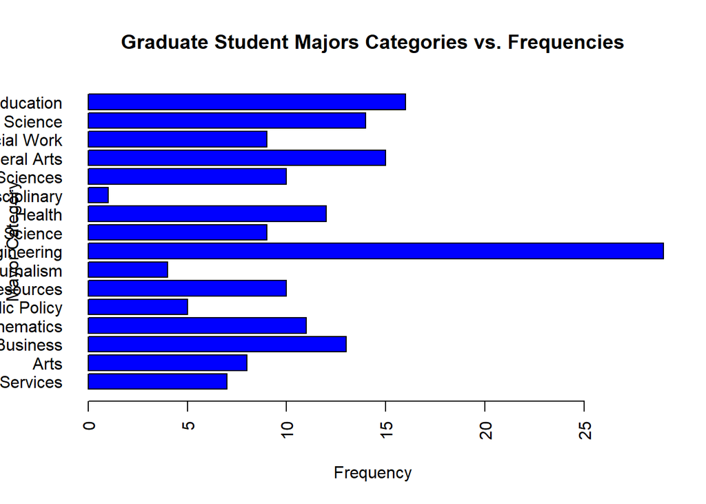

```r
#Create plot
par(las=2)
barplot(Counts, main= "Graduate Student Majors Categories vs. Frequencies", horiz=TRUE, xlab="Frequency", ylab="Mayor Category", names.arg = MajorCategory, col="blue")
```

## d. Write the fivethirtyeight data to a csv file. Make sure that it does not have row labels.

```r
#Save data as csv
write.csv(df, "fivethirtyeight.csv",row.names=F)
```

## 3. Codebook (30 points):

## a. Start a new repository on GitHub for your SMU MSDS homework. On your local device, make sure there is a directory for Homework at the minimum; you are welcome to add whatever you would like to this repo in addition to your requirements here.

## b. Create a README.md file which explains the purpose of the repository, the topics included, the sources for the material you post, and contact information in case of questions. Remember, the one in the root directory should be general. You are welcome to make short READMEs for each assignment individually in other folders.

## c. In one (or more) of the nested directories, post your RMarkdown script, HTML file, and data from ‘fivethirtyeight.’ Make sure that in your README or elsewhere that you credit fivethirtyeight in some way.

## d. In your RMarkdown script, please provide the link to this GitHub so the grader can see it.

## Github link https://github.com/meliluza/SMU-MSDS-6306